# MTHS3003_Coursework_20498015_Solutions

Akshay Bhandari

11 December 2022

```r
Coffee_Tuesday=read.csv("Coffee_Tuesday_20498015.csv")
Coffee_early=read.csv("Coffee_early_20498015.csv")
Coffee_weekend=read.csv("Coffee_weekend_20498015.csv")
Coffee_income=read.csv("Coffee_income_20498015.csv")
```

1. Provide an exploratory analysis of the number of customers served in 5 minute intervals using the data provided in Coffee_Tuesday_20498015.csv .

```r
mean(Coffee_Tuesday$Number.served) #MEAN
```

```
## [1] 5.516667
```

```r
max(Coffee_Tuesday$Number.served) #MAXIMUM NUMBER OF CUSTOMERS VISITING IN A 5 MINUTE INTERVAL
```

```
## [1] 12
```

```r
min(Coffee_Tuesday$Number.served) #MINIMUM NUMBER OF CUSTOMERS VISITING IN A 5 MINUTE INTERVAL
```

```
## [1] 0
```

```r
summary(Coffee_Tuesday$Number.served) #SUMMARY OF THE DATA INCLUDING THE INTERQUARTILE RANGES
```

```
##    Min. 1st Qu.  Median    Mean 3rd Qu.    Max.
##   0.000   3.000   5.000   5.517   7.000  12.000
```

```r
var(Coffee_Tuesday$Number.served) #VARIANCE
```

```
## [1] 8.890476
```

```r
sd(Coffee_Tuesday$Number.served) #STANDARD DEVIATION
```

```
## [1] 2.98169
```

```r
timeslot1=Coffee_Tuesday$Number.served[1:24] #DATA DIVIDED FOR 8AM-10AM
timeslot2=Coffee_Tuesday$Number.served[25:48] #DATA DIVIDED FOR 10AM-12PM
timeslot3=Coffee_Tuesday$Number.served[49:72] #DATA DIVIDED FOR 12PM-2M
timeslot4=Coffee_Tuesday$Number.served[73:96] #DATA DIVIDED FOR 2PM-4PM
timeslot5=Coffee_Tuesday$Number.served[97:120] #DATA DIVIDED FOR 4PM-6PM

sumtimeslot=0
sumtimeslot[1]=sum(timeslot1)
sumtimeslot[2]=sum(timeslot2)
sumtimeslot[3]=sum(timeslot3)
sumtimeslot[4]=sum(timeslot4)
sumtimeslot[5]=sum(timeslot5)
sumtimeslot
```

```
## [1] 171 139 163 139  50
```

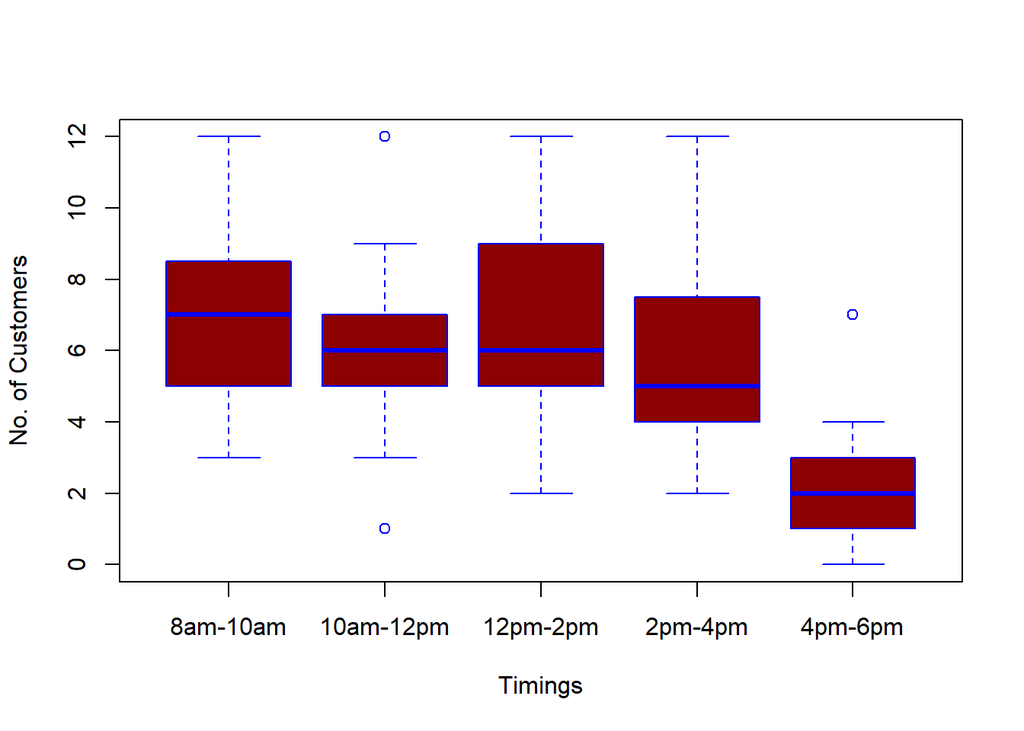

```r
meantimeslot=0
meantimeslot[1]=mean(timeslot1)
meantimeslot[2]=mean(timeslot2)
meantimeslot[3]=mean(timeslot3)
meantimeslot[4]=mean(timeslot4)
meantimeslot[5]=mean(timeslot5)

boxplot(timeslot1,timeslot2,timeslot3,timeslot4,timeslot5,xlab="Timings",ylab="No. of Customers",names=c("8am-10am","10am-12pm","12pm-2pm","2pm-4pm","4pm-6pm"),col=c("darkred"),border="blue")
```

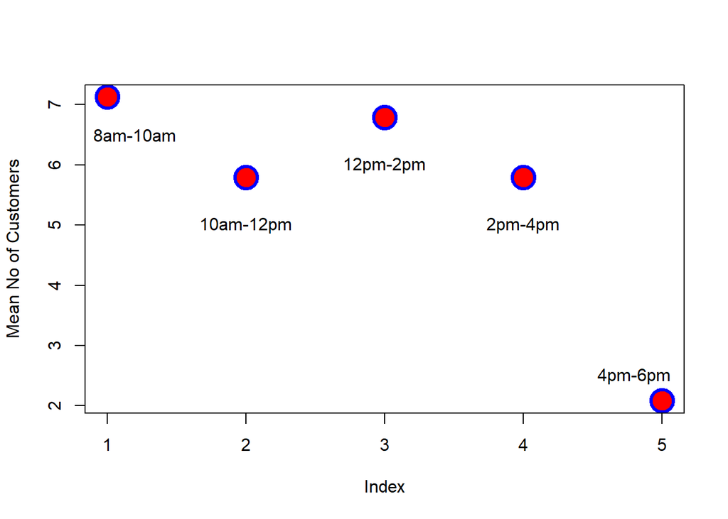

```r
plot(meantimeslot[1:5],bg='red',col='blue',lwd=3,cex=3,pch=21,ylab="Mean No of Customers")
text(1.2,6.5,"8am-10am")
text(2,5,"10am-12pm")
text(3,6,"12pm-2pm")
text(4,5,"2pm-4pm")
text(4.8,2.5,"4pm-6pm")
```

2. The coffee owner proposes that customer demand in a 5 minute interval follows a X ~ Po($\lambda$) distribution. Estimate the customer demand during the weekday early morning (8:30-9am) busy period using Coffee_early_20498015.csv. Due to staff and space constraints, the maximum number of customers that can be served in a 5 minute interval is 12.
1. Find the maximum likelihood estimate of $\lambda$.

```r
lambda=mean(Coffee_early$Number.served)
round(lambda,3) #OBSERVED MEAN FROM THE DATA
```

```
## [1] 8.387
```

```r
n=length(Coffee_early$Number.served)
n #TOTAL NUMBER OF OBSERVATIONS
```

```
## [1] 300
```

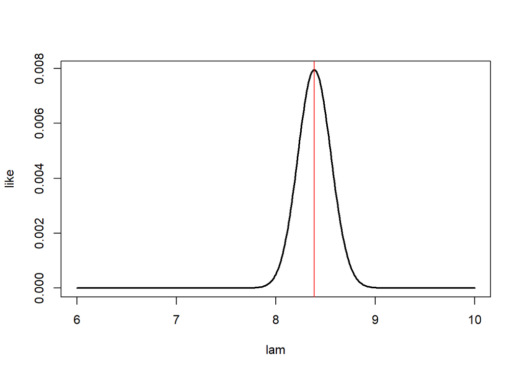

```r
t=sum(Coffee_early$Number.served) #TOTAL NUMBER OF CUSTOMERS VISITING THE COFFEE SHOP
lam = seq(6, 10, by=.01) #SEQUENCE TO FIND THE LAMBDA VALUE IN
like = dpois(t, n*lam) #LIKELIHOOD FUNCTION
plot(lam, like, type="l", lwd=2)
abline(v = lambda, col="red") #LINE AT MAXIMUM LIKELIHOOD VALUE
```

```r
maxlam=lam[like==max(like)]
maxlam #MLE
```

```
## [1] 8.39
```

Note: Suppose that an extra member of staff would enable the coffee shop to serve an additional 3 customers per 5 minute interval if there is the demand

2. Estimate how often the extra member of staff will be busy.

```r
ppois(13,maxlam,lower.tail = FALSE,log=FALSE) #PROBABILITY OF GETTING 13 OR MORE CUSTOMERS IN A 5 MINUTE INTERVAL
```

```
## [1] 0.04719109
```

```r
##CONCLUDED IN THE REPORT
```

3. Given that an extra member of staff would cost 20 per hour and the average profit per customer is 2.10, is it worth the owner having an extra member of staff between 8:30-9:00am?

```r
profitpercustomer= 3*2.1
costofextrastaff=20
profitearned=profitpercustomer-costofextrastaff/2
##EXPLAINED IN THE REPORT
```

3. The coffee shop owner suspects that the early morning busy period varies by day of the week.
1. Does the data in Coffee_early_20498015.csv support the coffee owners suspicions?

```r
earlymonday=Coffee_early$Number.served[Coffee_early$Day=='Monday']
earlytuesday=Coffee_early$Number.served[Coffee_early$Day=='Tuesday']
earlywednesday=Coffee_early$Number.served[Coffee_early$Day=='Wednesday']
earlythursday=Coffee_early$Number.served[Coffee_early$Day=='Thursday']
earlyfriday=Coffee_early$Number.served[Coffee_early$Day=='Friday']

meanearly=0
meanearly[1]=mean(earlymonday)
meanearly[2]=mean(earlytuesday)
meanearly[3]=mean(earlywednesday)
meanearly[4]=mean(earlythursday)
meanearly[5]=mean(earlyfriday)
meanearly #VECTOR WITH MEAN VALUES FOR EACH WEEKDAYS
```

```
## [1] 7.033333 8.416667 8.100000 9.383333 9.000000
```

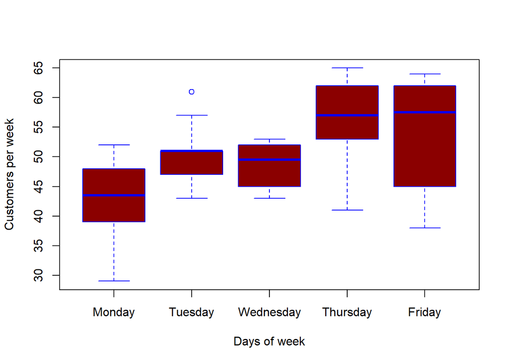

```r
mondaydata<-rep(NA,10) #VECTOR WITH 10 'NA' OBJECTS FOR EACH DAY
tuesdaydata<-rep(NA,10)
wednesdaydata<-rep(NA,10)
thursdaydata<-rep(NA,10)
fridaydata<-rep(NA,10)
for(i in 1:10){
  mondaydata[i]=sum(Coffee_early$Number.served[Coffee_early$Week == i & Coffee_early$Day == "Monday"])
  tuesdaydata[i]=sum(Coffee_early$Number.served[Coffee_early$Week == i & Coffee_early$Day == "Tuesday"])
  wednesdaydata[i]=sum(Coffee_early$Number.served[Coffee_early$Week == i & Coffee_early$Day == "Wednesday"])
  thursdaydata[i]=sum(Coffee_early$Number.served[Coffee_early$Week == i & Coffee_early$Day == "Thursday"])
  fridaydata[i]=sum(Coffee_early$Number.served[Coffee_early$Week == i & Coffee_early$Day == "Friday"])
} #THIS LOOP STORES SUM OF ALL CUSTOMERS ON SPECIFIC WEEKDAYS , PER WEEK BASIS

boxplot(mondaydata,tuesdaydata,wednesdaydata,thursdaydata,fridaydata,xlab="Days of week",ylab="Customers per week",names=c("Monday","Tuesday","Wednesday","Thursday","Friday"),col=c("darkred"),border="blue")
```

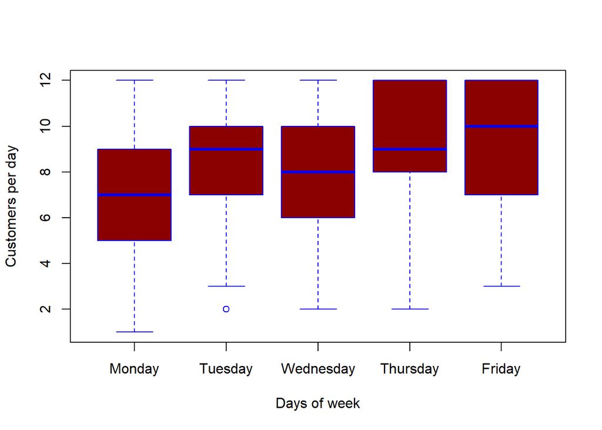

```r
boxplot(earlymonday,earlytuesday,earlywednesday,earlythursday,earlyfriday,xlab="Days of week",ylab="Customers per day",names=c("Monday","Tuesday","Wednesday","Thursday","Friday"),col=c("darkred"),border="blue")
```

```r
##CONCLUSIONS ABOUT THIS IS MADE IN THE RERPOT
```

2. How does the answer to question 3.(a) affect the conclusions drawn in question 2?

```r
#CONCLUSION GIVEN IN THE REPORT
```

4. The coffee shop owner is interested in weekend customer numbers. Use the data in Coffee_weekend_20498015.csv to address the following questions and discuss your conclusions.
1. Are the data consistent with the coffee shop owners assumption that the mean number of customers on Saturdays and Sundays are 250 and 230, respectively?

```r
data_saturday=Coffee_weekend$Saturday
t.test(data_saturday , mu=250)#TESTING MEAN OF SATURDAY AGAINST THE MEAN 250
```

```
##
##  One Sample t-test
##
## data:  data_saturday
## t = -0.17699, df = 9, p-value = 0.8634
## alternative hypothesis: true mean is not equal to 250
## 95 percent confidence interval:
##  201.7659 291.2341
## sample estimates:
## mean of x
##     246.5
```

```r
data_sunday=Coffee_weekend$Sunday
t.test(data_sunday , mu=230)#TESTING MEAN OF SUNDAY AGAINST THE MEAN 230
```

```
##
##  One Sample t-test
##
## data:  data_sunday
## t = -0.40919, df = 9, p-value = 0.692
## alternative hypothesis: true mean is not equal to 230
## 95 percent confidence interval:
##  188.8712 258.5288
## sample estimates:
## mean of x
##     223.7
```

2. Are the data consistent with the coffee shop owners assumption that the mean difference in the number of customers between Saturday and Sunday is at least 20?

```r
t.test(data_saturday , data_sunday ,mu=20, alternative = "less")#TESTING MEAN DIFFERENCE BETWEEN SATURDAY AND SUNDAY
```

```
##
##  Welch Two Sample t-test
##
## data:  data_saturday and data_sunday
## t = 0.11172, df = 16.979, p-value = 0.5438
## alternative hypothesis: true difference in means is less than 20
## 95 percent confidence interval:
##      -Inf 66.40081
## sample estimates:
## mean of x mean of y
##     246.5     223.7
```

5. The coffee shop owner wants to know how income per day (response variable) depends on the following covariates:

. Day of the week

. Mean number of staff working throughout the day

. Number of meal options

. Daily temperature (oC)

. Term time (yes/no)

1. Find the best model for predicting income using the data in Coffee_income_20498015.csv.

```r
income=Coffee_income$Income #LOADING INCOME DATA
weekday=Coffee_income$Weekday #LOADING DAY OF THE WEEK DATA
nostaff=Coffee_income$NoStaff #LOADING NUMBER OF STAFF DATA
term=Coffee_income$Term #LOADING TERM DATA
mealopt=Coffee_income$MealOpt #LOADING MEAL OPTIONS DATA
temp=Coffee_income$Temp #LOADING TEMPERATURE DATA
model<-lm(income~ weekday +nostaff + term + mealopt + temp) #MODEL WITH ALL COVARIATES
summary(model)
```

```
##
## Call:
## lm(formula = income ~ weekday + nostaff + term + mealopt + temp)
##
## Residuals:
##      Min       1Q   Median       3Q      Max
## -274.580  -64.446    7.113   79.064  220.631
##
## Coefficients:
##                  Estimate Std. Error t value Pr(>|t|)
## (Intercept)      2162.354    226.618   9.542 1.45e-13 ***
## weekdayMonday    -214.900     84.356  -2.548 0.013475 *
## weekdaySaturday  -174.336     75.402  -2.312 0.024282 *
## weekdaySunday    -271.676    118.346  -2.296 0.025270 *
## weekdayThursday  -135.339     91.980  -1.471 0.146497
## weekdayTuesday   -113.191     87.128  -1.299 0.198949
## weekdayWednesday  -84.299     83.419  -1.011 0.316362
## nostaff           130.852     34.823   3.758 0.000395 ***
## term               18.536     57.417   0.323 0.747963
## mealopt            22.715     27.385   0.829 0.410178
## temp                1.935      5.133   0.377 0.707579
## ---
## Signif. codes:  0 '***' 0.001 '**' 0.01 '*' 0.05 '.' 0.1 ' ' 1
##
## Residual standard error: 125.4 on 59 degrees of freedom
## Multiple R-squared:  0.5516, Adjusted R-squared:  0.4756
## F-statistic: 7.258 on 10 and 59 DF,  p-value: 2.382e-07
```

```r
AIC(model) #AIC OF THE FULL MODEL
```

```
## [1] 887.1496
```

```r
bestmodel<-step(model)#STEP FUNCTION TO FIND THE BEST FIT MODEL
```

```
## Start:  AIC=686.5
## income ~ weekday + nostaff + term + mealopt + temp
##
##           Df Sum of Sq     RSS    AIC
## - term     1      1640  930141 684.62
## - temp     1      2236  930736 684.67
## - mealopt  1     10828  939328 685.31
## <none>                  928501 686.50
## - weekday  6    209723 1138223 688.75
## - nostaff  1    222204 1150704 699.52
##
## Step:  AIC=684.62
## income ~ weekday + nostaff + mealopt + temp
##
##           Df Sum of Sq     RSS    AIC
## - temp     1      1984  932125 682.77
## - mealopt  1     13363  943504 683.62
## <none>                  930141 684.62
## - weekday  6    208683 1138823 686.79
## - nostaff  1    230484 1160625 698.12
##
## Step:  AIC=682.77
## income ~ weekday + nostaff + mealopt
##
##           Df Sum of Sq     RSS    AIC
## - mealopt  1     12686  944811 681.72
## <none>                  932125 682.77
## - weekday  6    207877 1140002 684.86
## - nostaff  1    233130 1165255 696.40
##
## Step:  AIC=681.72
## income ~ weekday + nostaff
##
##           Df Sum of Sq     RSS    AIC
## <none>                  944811 681.72
## - nostaff  1    256820 1201631 696.55
## - weekday  6    610603 1555414 704.61
```

```r
summary(bestmodel)
```

```
##
## Call:
## lm(formula = income ~ weekday + nostaff)
##
## Residuals:
##      Min       1Q   Median       3Q      Max
## -264.647  -54.168    5.319   78.478  225.432
##
## Coefficients:
##                  Estimate Std. Error t value Pr(>|t|)
## (Intercept)       2303.29     172.15  13.379  < 2e-16 ***
## weekdayMonday     -222.30      79.56  -2.794  0.00692 **
## weekdaySaturday   -205.49      61.40  -3.347  0.00139 **
## weekdaySunday     -356.54      58.97  -6.047 9.28e-08 ***
## weekdayThursday   -164.18      78.63  -2.088  0.04092 *
## weekdayTuesday    -165.67      57.62  -2.875  0.00553 **
## weekdayWednesday  -136.40      57.10  -2.389  0.01995 *
## nostaff            132.88      32.37   4.105  0.00012 ***
## ---
## Signif. codes:  0 '***' 0.001 '**' 0.01 '*' 0.05 '.' 0.1 ' ' 1
##
## Residual standard error: 123.4 on 62 degrees of freedom
## Multiple R-squared:  0.5437, Adjusted R-squared:  0.4922
## F-statistic: 10.56 on 7 and 62 DF,  p-value: 1.172e-08
```

```r
AIC(bestmodel)#AIC OF THE BEST FIT MODEL
```

```
## [1] 882.3685
```

2. Comment on the model fit and effect of the selected covariates on income.

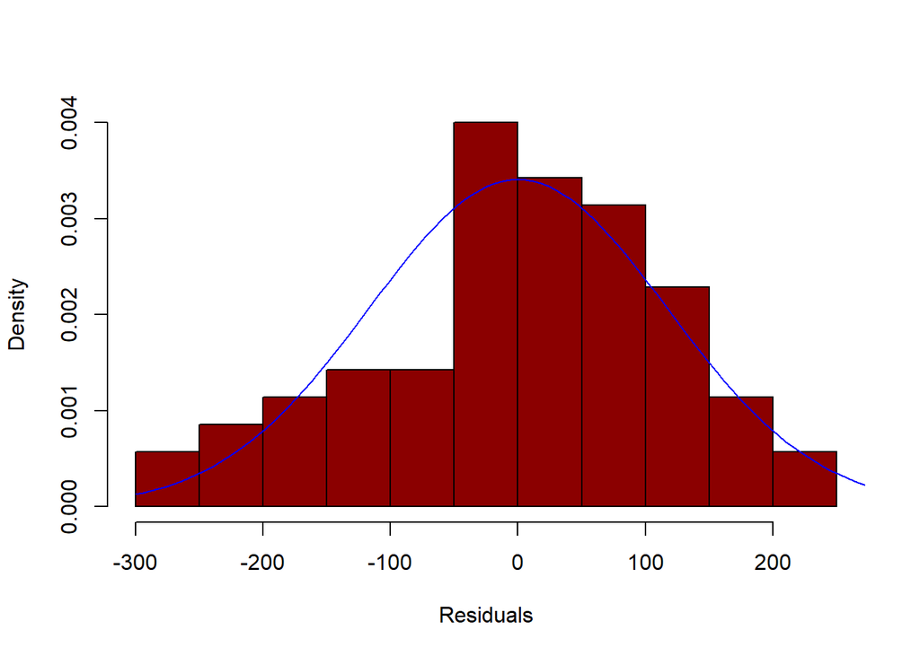

```r
hist(bestmodel$residuals,xlab="Residuals",col = "darkred",main="",freq=FALSE)#HISTOGRAM OF RESIDUALS TO CHECK NORMLITY
curve(dnorm(x,0,sd(bestmodel$residuals)),-300,300,col=4,add=TRUE)
```

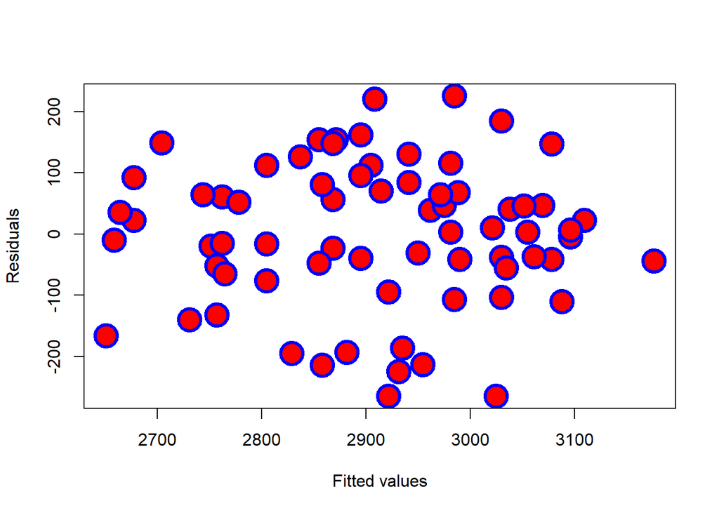

```r
plot(bestmodel$fitted.values,bestmodel$residuals,bg='red',col='blue',lwd=3,cex=3,pch=21,xlab="Fitted values",ylab="Residuals")
```

```r
##SCATTER PLOT TO CHECK HOMOGENITY
##COMMENTS MADE ARE IN THE REPORT
```

3. Estimate the level of income on a day with the following covariate information:

A Saturday in term time with daily temperature 15.9oC, on average 5 members of staff working and 4 meal options.

```r
pred<-predict(model,newdata=data.frame(weekday='Saturday',term=1,temp=15.9,nostaff=5,mealopt=4))
pred #PREDICTING INCOME AT THE ABOVE COVARIATES VALUES FOR OUR FULL MODEL
```

```
##        1
## 2782.439
```

```r
predbestmodel<-predict(bestmodel,newdata=data.frame(weekday='Saturday',term=1,temp=15.9,nostaff=5,mealopt=4))
predbestmodel #PREDICTING INCOME AT THE ABOVE COVARIATES VALUES FOR OUR BEST MODEL
```

```
##        1
## 2762.192
```